# Project Title: Surviving the Storm: How Economic Downturns Reshape Investor’s Investment Strategies Across the Globe

# Project 1

## Introduction

```
This research aims to analyze whether economic downturns, specifically the 2008 financial crisis, have reshaped investors' investment strategies. According to Investment Cycle Theory, it emphasizes that econmic downturns create risks aversion in investors, leading to fewer but more selective investments.(Kenton) This project utilizes a comprehensive Startup Investment dataset from Kaggle, supplemented by a Macro dataset containing information on inflation, interest rates, and unemployment rates across various countries, with the focus on the period from 2000 to 2013. This timeframe allows for a comparative analysis of investment behaviors before, during, and after the crisis.


The null hypothesis of this research question is during the significant economic downturn such as financial crisis, investors will choose the strategy of decreasing the funding amount to the startups. The x-variables will contain both inflation and unemployment rate from macro-economic perspectives, which are crucial defining the concept of economic downturns, and some categorial variables such as country and industry categories of the startups that investor's tend to invest. The categoric variables helped to define whether the strategies caused a change in the characteristics of startups that received higher amount of fundings.
```

```python
import pandas as pd
import numpy as np

from IPython.display import display
```

```python
objects = pd.read_csv("/Users/zzybollar/Downloads/archive/objects.csv")
objects = objects[["id", "entity_type","name", "category_code"]]
objects.groupby("category_code").count().sort_values("id", ascending=False)
objects
```

|  | id | entity_type | name | category_code |
| --- | --- | --- | --- | --- |
| 0 | c:1 | Company | Wetpaint | web |
| 1 | c:10 | Company | Flektor | games_video |
| 2 | c:100 | Company | There | games_video |
| 3 | c:10000 | Company | MYWEBBO | network_hosting |
| 4 | c:10001 | Company | THE Movie Streamer | games_video |
| ... | ... | ... | ... | ... |
| 462646 | r:9995 | Product | SiteLink, listing feed for Brokerages | NaN |
| 462647 | r:9996 | Product | EDCLink, listing feed for Economic Development... | NaN |
| 462648 | r:9997 | Product | Cmail, broadcast email marketing | NaN |
| 462649 | r:9998 | Product | CatylistCRM, contact database | NaN |
| 462650 | r:9999 | Product | Catylist Custom Print/Web Design | NaN |

462651 rows × 4 columns

```python
funds = pd.read_csv("/Users/zzybollar/Downloads/archive/funds.csv")
offices = pd.read_csv("/Users/zzybollar/Downloads/archive/offices.csv")
```

```python
investments = pd.read_csv("/Users/zzybollar/Downloads/archive/investments.csv")
investments = investments.dropna()
investments = investments.dropna(subset=['id', 'investor_object_id'])
investments = investments.drop(columns=['created_at', 'updated_at'])

investments = investments.merge(funds[['id', 'name']], on='id', how='left')
```

```python
ipos = pd.read_csv("/Users/zzybollar/Downloads/archive/ipos.csv")
ipos = ipos.dropna(subset=['public_at'])
ipos = ipos.drop(columns=['source_url','source_description','created_at', 'updated_at'])
ipos['public_year'] = pd.to_datetime(ipos['public_at'])
ipos['public_year'] = ipos['public_year'].dt.year
```

```python
funding_rounds = pd.read_csv("/Users/zzybollar/Downloads/archive/funding_rounds.csv")
```

```python
inflation_interest_unemployment = pd.read_csv("/Users/zzybollar/Downloads/archive/inflation interest unemployment.csv")
```

```python
milestones = pd.read_csv("/Users/zzybollar/Downloads/archive/milestones.csv")
```

```python
relationships = pd.read_csv("/Users/zzybollar/Downloads/archive/relationships.csv")
```

```python
wacc_global= pd.read_csv("/Users/zzybollar/Downloads/waccGlobal.csv")
wacc_global.columns=["Industry Name", "Number of Firms","Beta", "Cost of Equity", "E/(D+E)", "Std Dev in Stock", "Cost of Debt", "Tax Rate", "After-tax Cost of Debt", " D/(D+E)", "Cost of Capital"]
```

## Data Cleaning

```python
inflation_interest_unemployment['year'] = inflation_interest_unemployment['year'].astype(int)
inflation_interest_unemployment_2000_to_2013 = inflation_interest_unemployment[(inflation_interest_unemployment['year'] >= 2000) & (inflation_interest_unemployment['year'] <= 2013)]
inflation_interest_unemployment_2000_to_2013 = inflation_interest_unemployment_2000_to_2013.drop(columns=['Deposit interest rate (%)', 'Lending interest rate (%)', 'iso2c'])
inflation_interest_unemployment_2000_to_2013.dropna(inplace=True)
inflation_interest_unemployment_2000_to_2013.reset_index(drop=True, inplace=True)
```

```python
funding_rounds = pd.read_csv("/Users/zzybollar/Downloads/archive/funding_rounds.csv")
funding_rounds = funding_rounds.dropna()

funding_rounds['id'] = funding_rounds['id'].astype(str)
funds['id'] = funds['id'].astype(str)

funds = funds.merge(funding_rounds[['id', 'raised_amount_usd']], on='id', how='left')
funds = funds.drop(columns=['source_url', 'source_description', 'created_at', 'updated_at'])
```

```python
offices_cleaned = offices.dropna(subset=['city', 'region', 'zip_code','state_code'])
```

```python
funds['funded_at'] = pd.to_datetime(funds['funded_at'], errors='coerce')

start_date = "2000-01-01"
end_date = "2013-12-31"

funding_data = funds[(funds['funded_at'] >= start_date) & (funds['funded_at'] <= end_date)].copy()
funding_data = funding_data[["id"
                             , "fund_id", "object_id", "name", "funded_at", "raised_amount", "raised_currency_code"]]
funding_data.dropna(subset=["raised_amount"], inplace=True)
funding_data["raised_amount_log"] = np.log1p(funding_data["raised_amount"])
funding_data.reset_index(drop=True, inplace=True)
```

```python
wacc_global['Industry Name'] = wacc_global['Industry Name'].str.lower()
wacc_global['Industry Name'] = wacc_global['Industry Name'].str.replace(' ', '_')
wacc_global['Industry Name'] = wacc_global['Industry Name'].str.replace('-', '_')
wacc_global['Industry Name'] = wacc_global['Industry Name'].str.replace('&', '_')
wacc_global['Industry Name'] = wacc_global['Industry Name'].str.replace('(', '_')
wacc_global['Industry Name'] = wacc_global['Industry Name'].str.replace(')', '_')
wacc_global = wacc_global.dropna()
wacc_global = wacc_global.drop(index=17)
```

## Merge the data

```python
funding_rounds['id'] = funding_rounds['id'].astype(str)
merged_data1 = funding_rounds.merge(objects, left_on="object_id", right_on="id", how="left")
merged_data1 = merged_data1.drop(columns=["id_y","source_url","source_description","created_at","updated_at",
                                          "pre_money_valuation_usd","post_money_valuation_usd","post_money_valuation",
                                          "pre_money_valuation","created_by"])
merged_data1.drop_duplicates(inplace=True)
merged_data1['year'] = pd.to_datetime(merged_data1['funded_at']).dt.year
merged_data1 = merged_data1[(merged_data1['year'] >= 2000) & (merged_data1['year'] <= 2013)]
```

```python
merged_data2 = offices.merge(inflation_interest_unemployment_2000_to_2013, left_on='country_code', right_on='iso3c', how='left')
merged_data2.dropna(subset=['year'], inplace=True)
merged_data2.drop(columns=['office_id','description','state_code','iso3c','created_at','updated_at'], inplace=True)
merged_data2['year'] = merged_data2['year'].astype(int)
merged_data2 = merged_data2[(merged_data2['year'] >= 2000) & (merged_data2['year'] <= 2013)]
merged_data2.dropna(subset=['year'], inplace=True)
merged_data2.drop_duplicates("country_code", inplace=True)
```

```python
merged_data = funding_rounds.merge(investments, on="funding_round_id", how="left", suffixes=('_funding', '_investment'))

merged_data = merged_data.merge(objects, left_on="funded_object_id", right_on="id", how="left", suffixes=('', '_object'))

merged_data = merged_data.merge(funds, on="object_id", how="left", suffixes=('', '_fund'))

merged_data = merged_data.merge(milestones, on="object_id", how="left", suffixes=('', '_milestone'))

merged_data = merged_data.merge(offices, on="object_id", how="left", suffixes=('', '_office'))

merged_data = merged_data.merge(ipos, on="object_id", how="left", suffixes=('', '_ipo'))
merged_data.drop(columns=['public_at','stock_symbol','public_year'], inplace=True)
merged_data.drop_duplicates("object_id", inplace=True)
```

```python
merged_data_combined = merged_data.merge(merged_data2, on='country_code', how='inner')
venture_funding = merged_data_combined[merged_data_combined['funding_round_type'] == 'venture']
venture_funding_sum = venture_funding.groupby('funding_round_type')['raised_amount'].sum().reset_index()
merged_data_combined['venture_funding'] = merged_data_combined['funding_round_type'].apply(lambda x: 1 if x == 'venture' else 0)
merged_data_combined['venture_funding_sum'] = merged_data_combined['raised_amount'].apply(lambda x: x if x > 0 else 0)
merged_data_combined['venture_funding_sum'] = merged_data_combined['venture_funding_sum'].fillna(0)
merged_data_combined['venture_funding_sum'] = merged_data_combined['venture_funding_sum'].astype(int)
merged_data_combined['venture_funding_sum'] = merged_data_combined['venture_funding_sum'].apply(lambda x: np.log1p(x))
```

```python
merged_data_combined['raised_amount_log'] = np.log1p(merged_data_combined['raised_amount'])
merged_data_combined['raised_amount_log'] = merged_data_combined['raised_amount_log'].fillna(0)
merged_data_combined['raised_amount_log'] = merged_data_combined['raised_amount_log'].astype(int)
merged_data_combined['raised_amount_log'] = merged_data_combined['raised_amount_log'].apply(lambda x: np.log1p(x))
```

```python
from thefuzz import process

def fuzzy_match(industry, industry_list):
    match, score = process.extractOne(industry, industry_list)
    return match if score >= 50 else None

merged_data_combined["category_code"] = merged_data_combined["category_code"].astype(str)

merged_data_combined["category_code"] = merged_data_combined["category_code"].apply(lambda x: fuzzy_match(x, wacc_global["Industry Name"].tolist()))
merged_data_combined = merged_data_combined.merge(wacc_global, left_on="category_code", right_on="Industry Name", how="left")
merged_data_combined.drop(columns=['Industry Name'], inplace=True)
merged_data_combined
```

|  | id_funding | funding_round_id | object_id_x | funded_at | funding_round_type | funding_round_code | raised_amount_usd | raised_amount | raised_currency_code | pre_money_valuation_usd | ... | Number of Firms | Beta | Cost of Equity | E/(D+E) | Std Dev in Stock | Cost of Debt | Tax Rate | After-tax Cost of Debt | D/(D+E) | Cost of Capital |
| --- | --- | --- | --- | --- | --- | --- | --- | --- | --- | --- | --- | --- | --- | --- | --- | --- | --- | --- | --- | --- | --- |
| 0 | 270 | 270 | c:322 | 2010-11-16 | series-a | a | 0.0 | 0.0 | USD | 0.0 | ... | 417 | 1.25 | 11.74% | 78.09% | 47.41% | 6.82% | 14.38% | 5.10% | 21.91% | 10.29% |
| 1 | 1042 | 1042 | c:1448 | 2007-11-01 | series-c+ | c | 25000000.0 | 25000000.0 | USD | 0.0 | ... | 82 | 0.77 | 8.96% | 89.50% | 36.84% | 6.57% | 13.80% | 4.91% | 10.50% | 8.53% |
| 2 | 1525 | 1525 | c:2235 | 2007-01-15 | series-a | a | 3700000.0 | 3700000.0 | USD | 0.0 | ... | 165 | 1.07 | 10.68% | 74.20% | 33.42% | 6.57% | 18.87% | 4.91% | 25.80% | 9.19% |
| 3 | 2372 | 2372 | c:5693 | 2008-05-22 | series-a | a | 1000000.0 | 1000000.0 | USD | 0.0 | ... | 417 | 1.25 | 11.74% | 78.09% | 47.41% | 6.82% | 14.38% | 5.10% | 21.91% | 10.29% |
| 4 | 3666 | 3666 | c:12408 | 2008-08-01 | series-a | a | 4000000.0 | 4000000.0 | USD | 0.0 | ... | 113 | 0.85 | 9.44% | 73.97% | 33.87% | 6.57% | 20.12% | 4.91% | 26.03% | 8.26% |
| ... | ... | ... | ... | ... | ... | ... | ... | ... | ... | ... | ... | ... | ... | ... | ... | ... | ... | ... | ... | ... | ... |
| 439 | 57853 | 57853 | c:236066 | 2013-12-11 | series-a | a | 8000000.0 | 8000000.0 | USD | 0.0 | ... | 151 | 1.29 | 11.97% | 51.96% | 34.98% | 6.57% | 12.18% | 4.91% | 48.04% | 8.58% |
| 440 | 57866 | 57866 | c:51014 | 2013-12-12 | venture | unattributed | 0.0 | 0.0 | USD | 0.0 | ... | 311 | 1.26 | 11.78% | 96.30% | 52.92% | 6.82% | 11.27% | 5.10% | 3.70% | 11.53% |
| 441 | 57867 | 57867 | c:286063 | 2013-12-12 | venture | unattributed | 0.0 | 0.0 | USD | 0.0 | ... | 621 | 0.80 | 9.13% | 27.39% | 23.78% | 6.12% | 21.64% | 4.58% | 72.61% | 5.82% |
| 442 | 57868 | 57868 | c:286065 | 2013-12-12 | venture | unattributed | 0.0 | 0.0 | USD | 0.0 | ... | 804 | 0.98 | 10.17% | 72.76% | 35.22% | 6.57% | 15.54% | 4.91% | 27.24% | 8.73% |
| 443 | 57876 | 57876 | c:286114 | 2010-01-29 | venture | partial | 100000.0 | 100000.0 | USD | 0.0 | ... | 151 | 1.29 | 11.97% | 51.96% | 34.98% | 6.57% | 12.18% | 4.91% | 48.04% | 8.58% |

444 rows × 97 columns

## Summary Statistics tables by time period (before, during and after crisis)

[output not shown]

```python
before_crisis_end = "2007-09-30"
during_crisis_start = "2007-10-01"
during_crisis_end = "2009-06-30"
after_crisis_start = "2009-07-01"
```

```python
funding_before_crisis = merged_data_combined[(merged_data_combined['funded_at'] >= "2000-01-01") & (merged_data_combined['funded_at'] <= before_crisis_end)]
funding_during_crisis = merged_data_combined[(merged_data_combined['funded_at'] >= during_crisis_start) & (merged_data_combined['funded_at'] <= during_crisis_end)]
funding_after_crisis = merged_data_combined[(merged_data_combined['funded_at'] >= after_crisis_start) & (merged_data_combined['funded_at'] <= "2013-12-31")]
```

```python
def drop_duplicate_columns(df):
    duplicate_columns = df.columns[df.columns.duplicated()]
    df = df.loc[:, ~df.columns.duplicated()]
    return df

funding_before_crisis = drop_duplicate_columns(funding_before_crisis)
funding_during_crisis = drop_duplicate_columns(funding_during_crisis)
funding_after_crisis = drop_duplicate_columns(funding_after_crisis)
```

```python
funding_before_crisis.describe().drop(columns=
                                      ['fund_id','funded_at_fund','raised_amount_fund','pre_money_valuation_usd', 'pre_money_valuation',
                                       'post_money_valuation_usd', 'post_money_valuation'])
```

|  | funding_round_id | raised_amount_usd | raised_amount | participants | is_first_round | is_last_round | id_investment | raised_amount_usd_fund | id_milestone | id_office | ... | longitude_y | year | Inflation, consumer prices (annual %) | Inflation, GDP deflator (annual %) | Real interest rate (%) | Unemployment, total (% of total labor force) (national estimate) | Unemployment, total (% of total labor force) (modeled ILO estimate) | venture_funding | venture_funding_sum | raised_amount_log |
| --- | --- | --- | --- | --- | --- | --- | --- | --- | --- | --- | --- | --- | --- | --- | --- | --- | --- | --- | --- | --- | --- |
| count | 5.000000 | 5.000000e+00 | 5.000000e+00 | 5.000000 | 5.000000 | 5.000000 | 5.00000 | 0.0 | 1.0 | 5.00000 | ... | 5.000000 | 5.0 | 5.000000 | 5.000000 | 5.000000 | 5.000000 | 5.000000 | 5.000000 | 5.000000 | 5.000000 |
| mean | 10430.400000 | 1.250000e+07 | 1.250000e+07 | 2.400000 | 0.600000 | 0.600000 | 15303.00000 | NaN | 16619.0 | 21389.60000 | ... | 23.042402 | 2000.0 | 6.168554 | 10.930135 | 2.200282 | 9.878000 | 10.508200 | 0.200000 | 16.116289 | 2.820395 |
| min | 1525.000000 | 3.700000e+06 | 3.700000e+06 | 1.000000 | 0.000000 | 0.000000 | 2269.00000 | NaN | 16619.0 | 1632.00000 | ... | 0.000000 | 2000.0 | 0.347811 | 2.062793 | -9.633111 | 2.730000 | 3.260000 | 0.000000 | 15.123844 | 2.772589 |
| 25% | 9252.000000 | 6.000000e+06 | 6.000000e+06 | 1.000000 | 0.000000 | 0.000000 | 13762.00000 | NaN | 16619.0 | 20581.00000 | ... | 0.000000 | 2000.0 | 0.347811 | 2.062793 | 3.710664 | 3.100000 | 3.260000 | 0.000000 | 15.607270 | 2.772589 |
| 50% | 11948.000000 | 1.000000e+07 | 1.000000e+07 | 3.000000 | 1.000000 | 1.000000 | 16993.00000 | NaN | 16619.0 | 25853.00000 | ... | 0.000000 | 2000.0 | 4.009436 | 3.644970 | 3.710664 | 3.100000 | 5.561000 | 0.000000 | 16.118096 | 2.833213 |
| 75% | 13500.000000 | 1.800000e+07 | 1.800000e+07 | 3.000000 | 1.000000 | 1.000000 | 19510.00000 | NaN | 16619.0 | 27850.00000 | ... | 37.617633 | 2000.0 | 5.338951 | 9.182191 | 4.870582 | 10.580000 | 10.580000 | 0.000000 | 16.705882 | 2.833213 |
| max | 15927.000000 | 2.480000e+07 | 2.480000e+07 | 4.000000 | 1.000000 | 1.000000 | 23981.00000 | NaN | 16619.0 | 31032.00000 | ... | 77.594376 | 2000.0 | 20.798761 | 37.697928 | 8.342611 | 29.879999 | 29.879999 | 1.000000 | 17.026354 | 2.890372 |
| std | 5536.987927 | 8.767554e+06 | 8.767554e+06 | 1.341641 | 0.547723 | 0.547723 | 8187.22282 | NaN | NaN | 11679.58879 | ... | 34.573155 | 0.0 | 8.472825 | 15.247157 | 6.882049 | 11.657071 | 11.234093 | 0.447214 | 0.777800 | 0.049488 |

8 rows × 31 columns

```python
funding_during_crisis.describe().drop(columns=
                                      ['fund_id','funded_at_fund','raised_amount_fund','pre_money_valuation_usd', 'pre_money_valuation',
                                       'post_money_valuation_usd', 'post_money_valuation'])
```

|  | funding_round_id | raised_amount_usd | raised_amount | participants | is_first_round | is_last_round | id_investment | raised_amount_usd_fund | id_milestone | id_office | ... | longitude_y | year | Inflation, consumer prices (annual %) | Inflation, GDP deflator (annual %) | Real interest rate (%) | Unemployment, total (% of total labor force) (national estimate) | Unemployment, total (% of total labor force) (modeled ILO estimate) | venture_funding | venture_funding_sum | raised_amount_log |
| --- | --- | --- | --- | --- | --- | --- | --- | --- | --- | --- | --- | --- | --- | --- | --- | --- | --- | --- | --- | --- | --- |
| count | 14.000000 | 1.400000e+01 | 1.400000e+01 | 14.000000 | 14.000000 | 14.000000 | 14.000000 | 0.0 | 3.000000 | 14.000000 | ... | 14.000000 | 14.0 | 14.000000 | 14.000000 | 14.000000 | 14.000000 | 14.000000 | 14.000000 | 14.000000 | 14.000000 |
| mean | 9514.000000 | 2.605571e+07 | 2.605571e+07 | 2.285714 | 0.428571 | 0.642857 | 12386.214286 | NaN | 8500.333333 | 27852.714286 | ... | 22.001314 | 2000.0 | 4.313246 | 7.760717 | 2.875530 | 4.667143 | 4.826857 | 0.214286 | 16.299392 | 2.821469 |
| min | 1042.000000 | 1.000000e+06 | 1.000000e+06 | 1.000000 | 0.000000 | 0.000000 | 1526.000000 | NaN | 5581.000000 | 1153.000000 | ... | 0.000000 | 2000.0 | 0.347811 | 2.062793 | -9.633111 | 2.730000 | 3.260000 | 0.000000 | 13.815512 | 2.639057 |
| 25% | 4502.250000 | 6.335000e+06 | 6.335000e+06 | 1.000000 | 0.000000 | 0.000000 | 6021.500000 | NaN | 6986.000000 | 13760.750000 | ... | 0.000000 | 2000.0 | 0.347811 | 2.062793 | 3.710664 | 3.100000 | 3.260000 | 0.000000 | 15.651174 | 2.772589 |
| 50% | 6197.000000 | 1.000000e+07 | 1.000000e+07 | 2.000000 | 0.000000 | 1.000000 | 8725.500000 | NaN | 8391.000000 | 16586.500000 | ... | 0.000000 | 2000.0 | 0.347811 | 2.062793 | 3.710664 | 3.100000 | 3.260000 | 0.000000 | 16.118096 | 2.833213 |
| 75% | 7666.250000 | 2.400000e+07 | 2.400000e+07 | 3.000000 | 1.000000 | 1.000000 | 11389.500000 | NaN | 9960.000000 | 27526.500000 | ... | 37.617633 | 2000.0 | 4.009436 | 3.644970 | 4.535536 | 3.100000 | 5.561000 | 0.000000 | 16.990798 | 2.876082 |
| max | 51998.000000 | 1.030000e+08 | 1.030000e+08 | 5.000000 | 1.000000 | 1.000000 | 58143.000000 | NaN | 11529.000000 | 111502.000000 | ... | 77.594376 | 2000.0 | 20.798761 | 37.697928 | 8.342611 | 11.190000 | 10.580000 | 1.000000 | 18.450240 | 2.944439 |
| std | 12642.757702 | 3.356773e+07 | 3.356773e+07 | 1.266647 | 0.513553 | 0.497245 | 13976.935986 | NaN | 2975.506904 | 31034.084082 | ... | 32.952209 | 0.0 | 7.177591 | 12.730340 | 5.629065 | 3.320988 | 2.614052 | 0.425815 | 1.377252 | 0.084913 |

8 rows × 31 columns

```python
funding_after_crisis.describe().drop(columns=
                                      ['fund_id','funded_at_fund','raised_amount_fund','pre_money_valuation_usd', 'pre_money_valuation',
                                       'post_money_valuation_usd', 'post_money_valuation'])
```

|  | funding_round_id | raised_amount_usd | raised_amount | participants | is_first_round | is_last_round | id_investment | raised_amount_usd_fund | id_milestone | id_office | ... | longitude_y | year | Inflation, consumer prices (annual %) | Inflation, GDP deflator (annual %) | Real interest rate (%) | Unemployment, total (% of total labor force) (national estimate) | Unemployment, total (% of total labor force) (modeled ILO estimate) | venture_funding | venture_funding_sum | raised_amount_log |
| --- | --- | --- | --- | --- | --- | --- | --- | --- | --- | --- | --- | --- | --- | --- | --- | --- | --- | --- | --- | --- | --- |
| count | 425.000000 | 4.250000e+02 | 4.250000e+02 | 425.000000 | 425.000000 | 425.000000 | 326.000000 | 0.0 | 47.000000 | 425.000000 | ... | 425.000000 | 425.000000 | 425.000000 | 425.000000 | 425.000000 | 425.000000 | 425.000000 | 425.000000 | 425.000000 | 425.000000 |
| mean | 44068.527059 | 1.364969e+07 | 1.364767e+07 | 1.343529 | 0.851765 | 0.863529 | 55928.549080 | NaN | 24079.085106 | 87898.630588 | ... | 35.602881 | 2000.338824 | 5.354603 | 7.979103 | 7.807912 | 5.231882 | 6.417800 | 0.244706 | 10.945376 | 2.015790 |
| min | 270.000000 | 0.000000e+00 | 0.000000e+00 | 0.000000 | 0.000000 | 0.000000 | 453.000000 | NaN | 884.000000 | 293.000000 | ... | -80.097742 | 2000.000000 | -1.710337 | -3.169556 | -11.137956 | 2.260000 | 2.260000 | 0.000000 | 0.000000 | 0.000000 |
| 25% | 38907.000000 | 0.000000e+00 | 0.000000e+00 | 1.000000 | 1.000000 | 1.000000 | 51899.000000 | NaN | 16549.000000 | 77832.000000 | ... | 0.000000 | 2000.000000 | 1.591969 | 3.644970 | 3.710664 | 2.730000 | 3.260000 | 0.000000 | 0.000000 | 0.000000 |
| 50% | 44095.000000 | 1.000000e+06 | 1.000000e+06 | 1.000000 | 1.000000 | 1.000000 | 56109.000000 | NaN | 23319.000000 | 94321.000000 | ... | 37.617633 | 2000.000000 | 4.009436 | 3.644970 | 8.342611 | 2.730000 | 5.561000 | 0.000000 | 13.815512 | 2.639057 |
| 75% | 52019.000000 | 8.000000e+06 | 8.000000e+06 | 2.000000 | 1.000000 | 1.000000 | 60892.500000 | NaN | 33586.000000 | 105006.000000 | ... | 77.594376 | 2000.000000 | 5.338951 | 8.225094 | 8.342611 | 6.080000 | 5.561000 | 0.000000 | 15.894952 | 2.772589 |
| max | 57876.000000 | 7.000000e+08 | 7.000000e+08 | 15.000000 | 1.000000 | 1.000000 | 80795.000000 | NaN | 39402.000000 | 112684.000000 | ... | 105.837200 | 2011.000000 | 28.203097 | 37.697928 | 45.637819 | 29.879999 | 29.879999 | 1.000000 | 20.366591 | 3.044522 |
| std | 9546.636862 | 5.584922e+07 | 5.584963e+07 | 1.488830 | 0.355752 | 0.343692 | 10508.296439 | NaN | 10239.207266 | 23469.875871 | ... | 46.621024 | 1.481975 | 5.870348 | 10.339787 | 12.145597 | 4.876459 | 4.375107 | 0.430419 | 6.714247 | 1.192828 |

8 rows × 31 columns

## Plots, Figures

```python
import matplotlib.pyplot as plt
import statsmodels.formula.api as sm
import qeds
import seaborn as sns
import numpy as np
```

### Pie Chart

```
"Percentages of each category startup BEFORE/DURING/AFTER crisis" clearly shows the proportional distribution of each startup categories in the whole market. It provides a clear visualization of how different categories contribute to the overall startup economic system and could easily see the percentage change in 3 different time period. But there is a limitation that the whole market size are not shown, and it is undoubt that the datasize and whole market size are not the same.
```

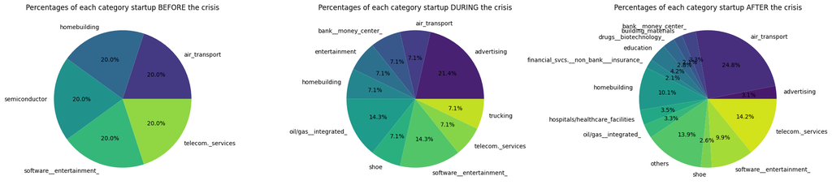

```python
def calculate_category_percenrtages(data):
    category_percentages = data["category_code"].value_counts(normalize=True) * 100
    category_percentages = category_percentages.reset_index()
    category_percentages.columns = ["category_code", "percentage"]
    category_percentages['category_code'] = category_percentages.apply(lambda row: 'others' if row['percentage'] < 2 else row['category_code'], axis=1)
    category_percentages = category_percentages.groupby('category_code')['percentage'].sum().reset_index()
    return category_percentages

category_percentages_before_crisis = calculate_category_percenrtages(funding_before_crisis)
category_percentages_during_crisis = calculate_category_percenrtages(funding_during_crisis)
category_percentages_after_crisis = calculate_category_percenrtages(funding_after_crisis)

def plot_pie_chart(ax, data, title):
    ax.pie(data["percentage"], labels=data["category_code"], autopct='%1.1f%%', colors=sns.color_palette("viridis", len(data)))
    ax.set_title(title)

fig, ax = plt.subplots(1, 3, figsize=(20, 6))

plot_pie_chart(ax[0],category_percentages_before_crisis, "Percentages of each category startup BEFORE the crisis")
plot_pie_chart(ax[1],category_percentages_during_crisis, "Percentages of each category startup DURING the crisis")
plot_pie_chart(ax[2],category_percentages_after_crisis, "Percentages of each category startup AFTER the crisis")

plt.tight_layout()
plt.show()
```

### Box Plot

```
"Distribution of funding amounts across startup categories" is a box plot of the distribution of funding amounts. This plot could know the average funding performance of each industry. It contains more details of mean, median, percentile information than the previous two visualizations. The variable for x and y-axis is appropriate since it is not hard to compare and see the difference. This graph concludes the statistics of mean, median and distribution clearly, which is helpful to conclude the funding performance of different categories. The higher funding amount of a category might due to larger number of firms in that specific category, or extreme high raised funding of top startups in that specific category.
```

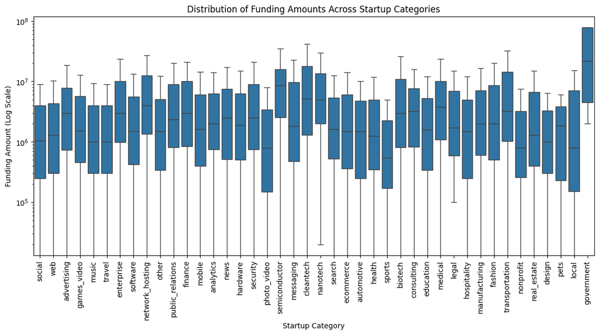

```python
plt.figure(figsize=(14, 6))
sns.boxplot(x="category_code", y="raised_amount", data=merged_data1, showfliers=False)
plt.xticks(rotation=90)
plt.yscale("log")
plt.title("Distribution of Funding Amounts Across Startup Categories")
plt.xlabel("Startup Category")
plt.ylabel("Funding Amount (Log Scale)")
plt.show()
```

### Line plot

```
The line plot clearly shows the flunctuation of inflation, and top 5 startup categories funding. Putting the change in total funding and inflation together allows for a clearer look at both at the same time.
```

```python
world_inflation_by_year = merged_data2.groupby('year')['Inflation, GDP deflator (annual %)'].mean().reset_index()
```

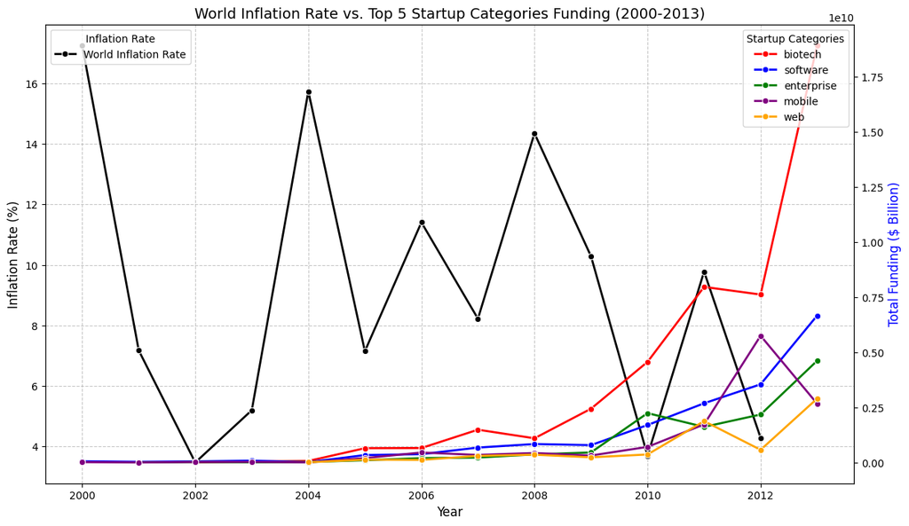

```python
merged_data1['funded_at'] = pd.to_datetime(merged_data1['funded_at'], errors='coerce')

merged_data1['year'] = merged_data1['funded_at'].dt.year

top_5_categories = merged_data1['category_code'].value_counts(normalize=True).nlargest(5).index

funding_by_category = merged_data1[merged_data1['category_code'].isin(top_5_categories)]
funding_trends = funding_by_category.groupby(['year', 'category_code'])['raised_amount'].sum().reset_index()

fig, ax1 = plt.subplots(figsize=(14, 8))

ax1.set_title('World Inflation Rate vs. Top 5 Startup Categories Funding (2000-2013)', fontsize=14)
ax1.set_xlabel('Year', fontsize=12)
ax1.set_ylabel('Inflation Rate (%)', fontsize=12, color='black')
sns.lineplot(data=world_inflation_by_year, x='year', y='Inflation, GDP deflator (annual %)',
             marker='o', label='World Inflation Rate', linewidth=2, color='black', ax=ax1)

ax2 = ax1.twinx()
ax2.set_ylabel('Total Funding ($ Billion)', fontsize=12, color='blue')

colors = ['red', 'blue', 'green', 'purple', 'orange']
for i, category in enumerate(top_5_categories):
    category_data = funding_trends[funding_trends['category_code'] == category]
    sns.lineplot(data=category_data, x='year', y='raised_amount', marker='o',
                 label=category, linewidth=2, color=colors[i], ax=ax2)

ax1.legend(loc='upper left', title="Inflation Rate", fontsize=10)
ax2.legend(loc='upper right', title="Startup Categories", fontsize=10)
ax1.grid(True, linestyle="--", alpha=0.7)

plt.show()
```

### Heatmap

```
The heatmap could visualize industry-specific investment trends and detect the impact of 2008 financial crisis. This graph shows that investors stopped investing on several industries during financial crisis period, especially real_estate, whereas some industries even get more investment during that time.
```

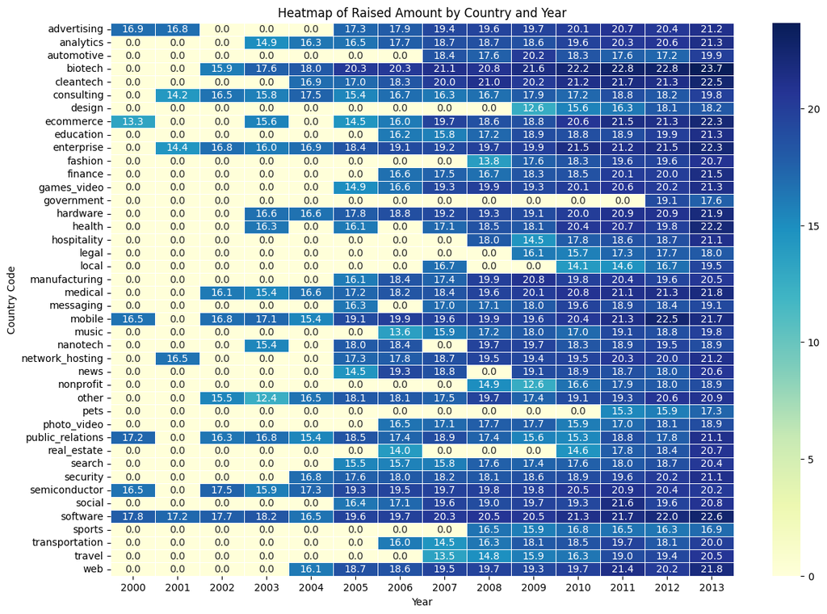

```python
df=merged_data1
df=df.pivot_table(values='raised_amount', index='category_code', columns='year', aggfunc='sum', fill_value=0)
df = np.log1p(df)
plt.figure(figsize=(14, 10))
sns.heatmap(df, cmap="YlGnBu", linewidths=0.5, annot=True, fmt=".1f")
plt.title("Heatmap of Raised Amount by Country and Year")
plt.xlabel("Year")
plt.ylabel("Country Code")
plt.show()
```

# Project 2

## The Message

```
My project is about how economic downturns reshape the investors' investing strategies. The economic downturns might have certain affect on investor's changing their investing strategies but there might also have certain other reasons such as reponse behavior could be non-random.(Author links open overlay panelAnnamaria Conti a b et al., 2018)
```

```python
import geopandas as gpd
from shapely.geometry import Point
world = gpd.read_file('/Users/zzybollar/Downloads/110m_cultural/ne_110m_admin_0_countries.shp')
```

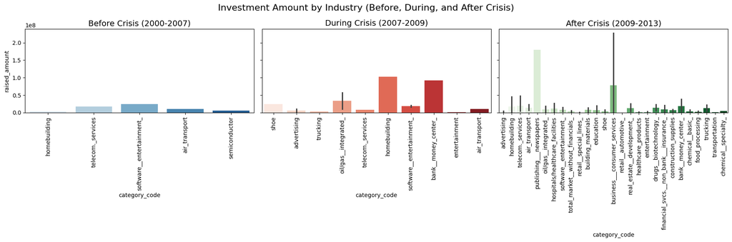

```python
funding_by_category_year = merged_data_combined.groupby(['category_code', 'year'])['raised_amount'].sum().reset_index()

fig, axes = plt.subplots(1, 3, figsize=(18, 6), sharey=True)

sns.barplot(data=funding_before_crisis, x='category_code', y='raised_amount', hue='category_code', palette='Blues', ax=axes[0], legend=False)
axes[0].set_title('Before Crisis (2000-2007)', fontsize=14)

sns.barplot(data=funding_during_crisis, x='category_code', y='raised_amount', hue='category_code', palette='Reds', ax=axes[1], legend=False)
axes[1].set_title('During Crisis (2007-2009)', fontsize=14)

sns.barplot(data=funding_after_crisis, x='category_code', y='raised_amount', hue='category_code', palette='Greens', ax=axes[2], legend=False)
axes[2].set_title('After Crisis (2009-2013)', fontsize=14)

for ax in axes:
    ax.set_xticks(range(len(ax.get_xticklabels())))
    ax.set_xticklabels(ax.get_xticklabels(), rotation=90)

plt.suptitle('Investment Amount by Industry (Before, During, and After Crisis)', fontsize=16)
plt.tight_layout()
plt.show()
```

## Map and Interpretations

```
Two groups of maps shows the total raised amount of high-/low- risks industries during three different time period. The geographic distribution and visualization highlights how different regions impact on the investing strategies or decisions of investors', and how investment strategies varied globally. It is not hard to tell that the raised amount for low-risks industries in some specific region has high stability that did not affected by the significant economic downturns. Whereas looking at the map for high-risks industries, we could see that the speed of the recovery of investment amount varies by continents, some area, for example Asia, showing a stronger rebounds. After the economic downturns, more area on the map were colored which might lead to a conclusion of the investor's tend to invest globally, however, this might also due to the lack of the data in some specific timeline such as before-crisis period and in some specific geographic area.
```

```python
import geopandas as gpd
from shapely.geometry import Point
world = gpd.read_file('/Users/zzybollar/Downloads/110m_cultural/ne_110m_admin_0_countries.shp')
```

```python
high_risk_industries = [
    'advertising', 'shoe', 'homebuilding', 'trucking', 'oil/gas__integrated_',
    'telecom._services', 'software__entertainment_', 'bank__money_center_',
    'air_transport', 'publishing___newspapers', 'entertainment', 'semiconductor',
    'real_estate__development_', 'retail__special_lines_', 'retail__automotive_',
    'financial_svcs.__non_bank___insurance_', 'chemical__basic_', 'chemical__specialty_'
]

low_risk_industries = [
    'hospitals/healthcare_facilities', 'education', 'healthcare_products',
    'drugs__biotechnology_', 'construction_supplies', 'food_processing',
    'transportation', 'building_materials', 'business___consumer_services'
]

funding_before_crisis['risk_category'] = funding_before_crisis['category_code'].apply(
	lambda x: 'High-Risk' if x in high_risk_industries else ('Low-Risk' if x in low_risk_industries else 'Other')
)
funding_during_crisis['risk_category'] = funding_during_crisis['category_code'].apply(
	lambda x: 'High-Risk' if x in high_risk_industries else ('Low-Risk' if x in low_risk_industries else 'Other')
)
funding_after_crisis['risk_category'] = funding_after_crisis['category_code'].apply(
	lambda x: 'High-Risk' if x in high_risk_industries else ('Low-Risk' if x in low_risk_industries else 'Other')
)
```

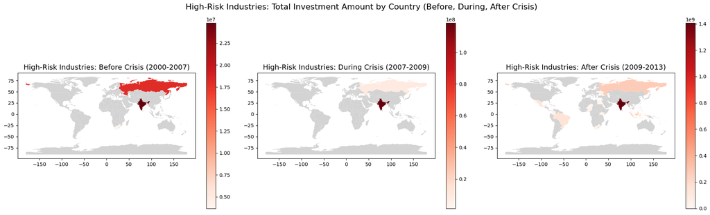

```python
high_risk_data_before = funding_before_crisis[funding_before_crisis['risk_category'] == 'High-Risk']
high_risk_data_during = funding_during_crisis[funding_during_crisis['risk_category'] == 'High-Risk']
high_risk_data_after = funding_after_crisis[funding_after_crisis['risk_category'] == 'High-Risk']

country_funding_before_crisis = high_risk_data_before.groupby("country_code")["raised_amount"].sum().reset_index()
country_funding_during_crisis = high_risk_data_during.groupby("country_code")["raised_amount"].sum().reset_index()
country_funding_after_crisis = high_risk_data_after.groupby("country_code")["raised_amount"].sum().reset_index()

world_before_crisis = world.merge(country_funding_before_crisis, left_on="SOV_A3", right_on="country_code", how="left")
world_during_crisis = world.merge(country_funding_during_crisis, left_on="SOV_A3", right_on="country_code", how="left")
world_after_crisis = world.merge(country_funding_after_crisis, left_on="SOV_A3", right_on="country_code", how="left")

fig, axes = plt.subplots(1, 3, figsize=(20, 6))

world_before_crisis.plot(column='raised_amount', cmap='Reds', legend=True, ax=axes[0], missing_kwds={'color': 'lightgrey'})
axes[0].set_title('High-Risk Industries: Before Crisis (2000-2007)', fontsize=14)

world_during_crisis.plot(column='raised_amount', cmap='Reds', legend=True, ax=axes[1], missing_kwds={'color': 'lightgrey'})
axes[1].set_title('High-Risk Industries: During Crisis (2007-2009)', fontsize=14)

world_after_crisis.plot(column='raised_amount', cmap='Reds', legend=True, ax=axes[2], missing_kwds={'color': 'lightgrey'})
axes[2].set_title('High-Risk Industries: After Crisis (2009-2013)', fontsize=14)

plt.suptitle('High-Risk Industries: Total Investment Amount by Country (Before, During, After Crisis)', fontsize=16)
plt.tight_layout()
plt.show()
```

[figure not shown]

```python
Low_risk_data_before = funding_before_crisis[funding_before_crisis['risk_category'] == 'Low-Risk']
low_risk_data_during = funding_during_crisis[funding_during_crisis['risk_category'] == 'Low-Risk']
low_risk_data_after = funding_after_crisis[funding_after_crisis['risk_category'] == 'Low-Risk']

country_funding_before_crisis1 = Low_risk_data_before.groupby("country_code")["raised_amount"].sum().reset_index()
country_funding_during_crisis1 = low_risk_data_during.groupby("country_code")["raised_amount"].sum().reset_index()
country_funding_after_crisis1 = low_risk_data_after.groupby("country_code")["raised_amount"].sum().reset_index()

world_before_crisis1 = world.merge(country_funding_before_crisis1, left_on="SOV_A3", right_on="country_code", how="left")
world_during_crisis1 = world.merge(country_funding_during_crisis1, left_on="SOV_A3", right_on="country_code", how="left")
world_after_crisis1 = world.merge(country_funding_after_crisis1, left_on="SOV_A3", right_on="country_code", how="left")
fig, axes = plt.subplots(1, 3, figsize=(20, 6))

world_before_crisis1.plot(column='raised_amount', cmap='Greens', legend=True, ax=axes[0], missing_kwds={'color': 'lightgrey'})
axes[0].set_title('Low-Risk Industries: Before Crisis (2000-2007)', fontsize=14)

world_during_crisis1.plot(column='raised_amount', cmap='Greens', legend=True, ax=axes[1], missing_kwds={'color': 'lightgrey'})
axes[1].set_title('Low-Risk Industries: During Crisis (2007-2009)', fontsize=14)

world_after_crisis1.plot(column='raised_amount', cmap='Greens', legend=True, ax=axes[2], missing_kwds={'color': 'lightgrey'})
axes[2].set_title('Low-Risk Industries: After Crisis (2009-2013)', fontsize=14)

plt.suptitle('Low-Risk Industries: Total Investment Amount by Country (Before, During, After Crisis)', fontsize=16)
plt.tight_layout()
plt.show()
```

## Regressions

This is a regression equation: $$ logRaisedAmount = \beta_0 + \beta_1 \times \text{Macroeconomic interpretations} + \beta_2 \times \text{Categorial variables} + \beta_3 \times \text{Participants}+\beta_4\times\text{years} +\epsilon $$

### Regression table 1: with 4 models generating the Macroeconomic indicators Impacts on Total raised amount

```
Regression table 1 shows how the macro economic indicators such as inflation rate, real interest rate affect the total raised amount. The result, especially the result for model 8 in this regression model, suggests a diminishing return effect at higher funding levels. The R^2 of model 6 and 8 almost explains all variance. In summary, in this model we could conclude that the participants have negative impact in raise fundings, inflation and VC fundings are highly significant. We could interprets that macroeconomic factors are weak predictors of total funding amount, in other words, investor's is unlikely to change their strategies by decreasing the funding amount during significant economic downturns.
```

```python
import statsmodels.api as sm
from stargazer.stargazer import Stargazer

merged_data_combined['Inflation_Interest'] = merged_data_combined['Inflation, GDP deflator (annual %)'] * merged_data_combined['Real interest rate (%)']

merged_data_combined['venture_funding_sum_sq'] = merged_data_combined['venture_funding_sum'] ** 2

X1 = merged_data_combined[['Inflation, GDP deflator (annual %)', 'Real interest rate (%)']]
X1 = sm.add_constant(X1)
model1 = sm.OLS(merged_data_combined['raised_amount_log'], X1).fit()

X6 = merged_data_combined[['Inflation, GDP deflator (annual %)', 'Real interest rate (%)', 'participants', 'venture_funding_sum', 'year']]
X6 = sm.add_constant(X6)
model6 = sm.OLS(merged_data_combined['raised_amount_log'], X6).fit()

X7 = merged_data_combined[['Inflation, GDP deflator (annual %)', 'Real interest rate (%)', 'participants', 'venture_funding_sum', 'Inflation_Interest']]
X7 = sm.add_constant(X7)
model7 = sm.OLS(merged_data_combined['raised_amount_log'], X7).fit()

X8 = merged_data_combined[['Inflation, GDP deflator (annual %)', 'Real interest rate (%)', 'participants', 'venture_funding_sum', 'venture_funding_sum_sq']]
X8 = sm.add_constant(X8)
model8 = sm.OLS(merged_data_combined['raised_amount_log'], X8).fit()

stargazer = Stargazer([model1, model6, model7, model8])

stargazer.covariate_order([
    'const',
    'Inflation, GDP deflator (annual %)',
    'Real interest rate (%)',
    'participants',
    'venture_funding_sum',
    'year',
    'Inflation_Interest',
    'venture_funding_sum_sq'
])

stargazer.custom_columns(['Model 1', 'Model 6', 'Model 7', 'Model 8'], [1, 1, 1, 1])

stargazer.title("Regression Results: Impact of Economic and Investment Factors on Funding")

from IPython.core.display import display, HTML
html_output = stargazer.render_html()
display(HTML(html_output))
```

Regression Results: Impact of Economic and Investment Factors on Funding

|  | *Dependent variable: raised_amount_log* |  |  |  |
| --- | --- | --- | --- | --- |
|  | Model 1 | Model 6 | Model 7 | Model 8 |
|  | (1) | (2) | (3) | (4) |
| const | 1.930*** | -16.584 | 0.084*** | 0.010** |
|  | (0.090) | (13.582) | (0.023) | (0.004) |
| Inflation, GDP deflator (annual %) | 0.014** | 0.005*** | 0.007*** | -0.000 |
|  | (0.006) | (0.001) | (0.002) | (0.000) |
| Real interest rate (%) | 0.001 | 0.002** | -0.001 | -0.000 |
|  | (0.005) | (0.001) | (0.002) | (0.000) |
| participants |  | -0.021*** | -0.020*** | -0.003*** |
|  |  | (0.007) | (0.007) | (0.001) |
| venture_funding_sum |  | 0.174*** | 0.174*** | 0.306*** |
|  |  | (0.001) | (0.001) | (0.001) |
| year |  | 0.008 |  |  |
|  |  | (0.007) |  |  |
| Inflation_Interest |  |  | 0.000 |  |
|  |  |  | (0.000) |  |
| venture_funding_sum_sq |  |  |  | -0.008*** |
|  |  |  |  | (0.000) |
| Observations | 444 | 444 | 444 | 444 |
| R<sup>2</sup> | 0.014 | 0.970 | 0.970 | 0.999 |
| Adjusted R<sup>2</sup> | 0.009 | 0.970 | 0.970 | 0.999 |
| Residual Std. Error | 1.173 (df=441) | 0.205 (df=438) | 0.204 (df=438) | 0.036 (df=438) |
| F Statistic | 3.020** (df=2; 441) | 2849.564*** (df=5; 438) | 2855.897*** (df=5; 438) | 94069.257*** (df=5; 438) |
| Note: | *p<0.1; **p<0.05; ***p<0.01 |  |  |  |

### Regression table 2: Regression Results: Impact of Categoric Factors on Funding

[output not shown]

```python
continent_mapping = {
    "USA": "North America", "CAN": "North America", "MEX": "North America",
    "BRA": "South America", "ARG": "South America", "CHL": "South America", "COL": "South America", "ECU": "South America",
    "GBR": "Europe", "IRL": "Europe", "FRA": "Europe", "DEU": "Europe", "ESP": "Europe", "NLD": "Europe", "ITA": "Europe",
    "CHE": "Europe", "DNK": "Europe", "NOR": "Europe", "SWE": "Europe", "FIN": "Europe", "POL": "Europe", "BEL": "Europe",
    "RUS": "Europe", "EST": "Europe", "LUX": "Europe", "AUT": "Europe", "GRC": "Europe", "ROM": "Europe", "LTU": "Europe",
    "CYP": "Europe", "PRT": "Europe", "CZE": "Europe", "BGR": "Europe", "UKR": "Europe", "MLT": "Europe", "ISL": "Europe",
    "CHN": "Asia", "IND": "Asia", "JPN": "Asia", "SGP": "Asia", "KOR": "Asia", "TWN": "Asia", "HKG": "Asia", "THA": "Asia",
    "IDN": "Asia", "MYS": "Asia", "VNM": "Asia", "PHL": "Asia", "JOR": "Asia", "ISR": "Asia", "TUR": "Asia", "KHM": "Asia",
    "PRK": "Asia",
    "AUS": "Oceania", "NZL": "Oceania", "NRU": "Oceania",
    "ZAF": "Africa", "NGA": "Africa", "KEN": "Africa", "EGY": "Africa", "SEN": "Africa", "GHA": "Africa", "MAR": "Africa",
    "UGA": "Africa", "SWZ": "Africa", "NER": "Africa",
    "ARE": "Middle East", "HMI": "Middle East", "ANT": "Middle East", "BMU": "Middle East", "GIB": "Middle East", "CYM": "Middle East",
    "SMR": "Middle East", "ALB": "Middle East"
}
```

```python
categories = ['advertising', 'shoe', 'homebuilding', 'trucking',
       'oil/gas__integrated_', 'telecom._services',
       'software__entertainment_', 'bank__money_center_', 'air_transport',
       'publishing___newspapers', 'entertainment', 'semiconductor',
       'hospitals/healthcare_facilities',
       'total_market__without_financials_', 'retail__special_lines_',
       'building_materials', 'education', 'business___consumer_services',
       'retail__automotive_', 'real_estate__development_',
       'healthcare_products', 'drugs__biotechnology_',
       'financial_svcs.__non_bank___insurance_', 'construction_supplies',
       'chemical__basic_', 'food_processing', 'transportation',
       'chemical__specialty_']
```

```python
funding_round_types = ['series-a', 'series-c+', 'series-b', 'venture', 'post-ipo', 'angel', 'other', 'private-equity', 'crowdfunding']
```

```python
import statsmodels.api as sm
from stargazer.stargazer import Stargazer
from IPython.core.display import display, HTML

n=500
np.random.seed(42)

data = {
    'country_code': np.random.choice(list(continent_mapping.keys()), n),
    'category_code': np.random.choice(categories, n),
    'funding_round_type': np.random.choice(funding_round_types, n),
    'participants': np.random.randint(1, 100, n),
    'venture_funding_sum': np.random.randint(1000, 10000, n),
    'raised_amount': np.random.uniform(10, 20, n)
}

data0 = pd.DataFrame(data)

data0['continent'] = data0['country_code'].map(continent_mapping)

data0['risk_category'] = data0['category_code'].apply(
    lambda x: 'High-Risk' if x in high_risk_industries else ('Low-Risk' if x in low_risk_industries else 'Other')
)

risk_dummies = pd.get_dummies(data0['risk_category'], prefix='risk', drop_first=False)
risk_dummies = risk_dummies.astype(int)
continent_dummies = pd.get_dummies(data0['continent'], prefix='continent', drop_first=False)
continent_dummies = continent_dummies.astype(int)
funding_round_dummies = pd.get_dummies(data0['funding_round_type'], prefix='round', drop_first=False)
funding_round_dummies = funding_round_dummies.astype(int)

data0 = pd.concat([data0, risk_dummies, continent_dummies, funding_round_dummies], axis=1)

X2 = data0[['participants', 'venture_funding_sum']]
X2 = sm.add_constant(X2)
model2 = sm.OLS(data0['raised_amount'], X2).fit()

X3 = data0[['continent_Asia', 'continent_Europe', 'continent_North America', 'continent_Oceania', 'continent_South America']]
X3 = sm.add_constant(X3)
model3 = sm.OLS(data0['raised_amount'], X3).fit()

X4 = data0[['risk_High-Risk', 'risk_Low-Risk']]
X4 = sm.add_constant(X4)
model4 = sm.OLS(data0['raised_amount'], X4).fit()

X5 = data0[[col for col in data0.columns if col.startswith('round_')]]
X5 = sm.add_constant(X5)
model5 = sm.OLS(data0['raised_amount'], X5).fit()

stargazer = Stargazer([model2, model3, model4, model5])

stargazer.covariate_order([
    'const',
    'participants', 'venture_funding_sum',
    'continent_Asia', 'continent_Europe', 'continent_North America', 'continent_Oceania', 'continent_South America',
    'risk_High-Risk', 'risk_Low-Risk',
    *[col for col in data0.columns if col.startswith('round_')]
])

stargazer.custom_columns(['Model 2', 'Model 3', 'Model 4', 'Model 5'], [1, 1, 1, 1])

stargazer.title("Regression Results: Impact of Categorical Factors on Funding")

html_output = stargazer.render_html()
display(HTML(html_output))
```

Regression Results: Impact of Categorical Factors on Funding

|  | *Dependent variable: raised_amount* |  |  |  |
| --- | --- | --- | --- | --- |
|  | Model 2 | Model 3 | Model 4 | Model 5 |
|  | (1) | (2) | (3) | (4) |
| const | 15.588*** | 15.351*** | 15.218*** | 13.435*** |
|  | (0.385) | (0.264) | (0.817) | (0.119) |
| participants | -0.003 |  |  |  |
|  | (0.005) |  |  |  |
| venture_funding_sum | -0.000* |  |  |  |
|  | (0.000) |  |  |  |
| continent_Asia |  | -0.504 |  |  |
|  |  | (0.390) |  |  |
| continent_Europe |  | -0.356 |  |  |
|  |  | (0.337) |  |  |
| continent_North America |  | -0.735 |  |  |
|  |  | (0.605) |  |  |
| continent_Oceania |  | -1.808** |  |  |
|  |  | (0.802) |  |  |
| continent_South America |  | -1.181** |  |  |
|  |  | (0.597) |  |  |
| risk_High-Risk |  |  | -0.219 |  |
|  |  |  | (0.834) |  |
| risk_Low-Risk |  |  | -0.425 |  |
|  |  |  | (0.849) |  |
| round_angel |  |  |  | 1.345*** |
|  |  |  |  | (0.391) |
| round_crowdfunding |  |  |  | 1.476*** |
|  |  |  |  | (0.378) |
| round_other |  |  |  | 2.110*** |
|  |  |  |  | (0.372) |
| round_post-ipo |  |  |  | 1.242*** |
|  |  |  |  | (0.366) |
| round_private-equity |  |  |  | 1.695*** |
|  |  |  |  | (0.343) |
| round_series-a |  |  |  | 1.535*** |
|  |  |  |  | (0.360) |
| round_series-b |  |  |  | 1.768*** |
|  |  |  |  | (0.369) |
| round_series-c+ |  |  |  | 0.754** |
|  |  |  |  | (0.378) |
| round_venture |  |  |  | 1.511*** |
|  |  |  |  | (0.415) |
| Observations | 500 | 500 | 500 | 500 |
| R<sup>2</sup> | 0.007 | 0.017 | 0.001 | 0.015 |
| Adjusted R<sup>2</sup> | 0.003 | 0.007 | -0.003 | -0.002 |
| Residual Std. Error | 2.938 (df=497) | 2.932 (df=494) | 2.946 (df=497) | 2.945 (df=491) |
| F Statistic | 1.771 (df=2; 497) | 1.684 (df=5; 494) | 0.326 (df=2; 497) | 0.904 (df=8; 491) |
| Note: | *p<0.1; **p<0.05; ***p<0.01 |  |  |  |

# Future steps:

```
In the future project, I will track the long-term effect propably by using most recent data to see the patterns of the investment and add the policy of different region to analyze since different policies in different region might also affect investors' investing strategies and behavior. Also, after studying ML, this will also be added into this project therefore to enhance the capabilities of analytics, developing models to predit how future economic downturns might affect the startup investments and predict what actions investors' might take. I will also do more research on classifiying the industry categories into high-/low-risks since most industry categories could not be simply classified as high/low risk industry, it's way more complex.
```

# Conclusion

```
It is undoubt that the significant economic downturns such as 2008 financial crisis will reshape the investment market.[4] But they are not affecting the investment market by reducing the total volume of investments, instead, they are changing the investment strategy and evaluation criteria of the investors for those startups. The effect brought by economic downturns are long_lasting and various from area to area due to different policies. After the economic has recovered from financial crisis, the investment for safer and basic category has increase. The investors' investing strategies and invested history, government policy, and country's overall economic performances will be really helpful for those who is planning to start their entity and want to seek investors.
```

# Citations:

[1]Kenton, W. (n.d.). Market cycles: Definition, how they work, and types. Investopedia. https://www.investopedia.com/terms/m/market_cycles.asp

[2]Gompers, P., Gornall, W., Kaplan, S. N., & Strebulaev, I. A. (2020). How do venture capitalists make decisions? Journal of Financial Economics, 135(1), 169–190. https://doi.org/10.1016/j.jfineco.2019.06.011

[3]Chen, S.-H., & Tsai, C.-H. (2011). Investment preference, risk perception, and portfolio choices under different socio-economic status: Some experimental evidences from individual investors. SSRN Electronic Journal. https://doi.org/10.2139/ssrn.1787842

[4]Conti, A., Dass, N., Di Lorenzo, F., & Graham, S. J. H. (2019). Venture capital investment strategies under financing constraints: Evidence from the 2008 financial crisis. Research Policy, 48(3), 799–812. https://doi.org/10.1016/j.respol.2018.11.009

[5]Carniel, T., Gastaud, C., & Dalle, J. M. (2019). The temporal evolution of venture investment strategies in sector space. arXiv preprint arXiv:1906.01980. https://doi.org/10.48550/arXiv.1906.01980

[6]Author links open overlay panelArvid O.I. Hoffmann a b, a, b, c, d, e, AbstractCombining monthly survey data with matching trading records, Aloui, R., Bailey, W., Bauer, R., Baur, D. G., Glaser, M., Güntay, L., Jin, J. Y., Kahneman, D., Kapteyn, A., Lam, C. F., Longstaff, F. A., Moshirian, F., … Driscoll, J. C. (2012, August 23). Individual investor perceptions and behavior during the financial crisis. Journal of Banking & Finance. https://www.sciencedirect.com/science/article/abs/pii/S0378426612002294